# Explanatory Data Analysis: Understanding Borrower Risk and Loan Outcomes

### Objective

In this analysis, we focus on answering the central question:

> **What borrower characteristics are most associated with loan outcomes and potential lending risk?**

Rather than exploring the entire dataset broadly, we narrow our lens to uncover key insights about how employment status, debt-to-income ratio, and borrower rates relate to whether a loan ends up closed or remains open. The goal is to present these findings in a clear, story-driven manner supported by visual evidence.

### Dataset Context

The dataset is sourced from **Prosper**, a peer-to-peer lending platform, and contains **over 113,000 loans** and **81 variables** covering borrower profiles, loan terms, risk scores, and financial behaviors. This rich data environment allows us to examine real-world lending dynamics and borrower behavior at scale.

### Why This Matters

Understanding the patterns that distinguish **closed vs. open loans** can help lenders:

- Identify risk indicators early
- Adjust loan offers based on borrower profiles
- Develop more fair and data-driven lending models

This analysis is structured to **guide the reader** through the most relevant patterns — using well-designed, annotated visuals — and ultimately provide a **narrative that connects data to insight**.

Let’s begin the journey into the data.

```python
import numpy as np
import pandas as pd
import matplotlib.pyplot as plt
import seaborn as sns
```

```python
df = pd.read_csv(r"C:\Users\Waseem\OneDrive\Desktop\EDA\cleaned_data.csv")
df.head()
```

|  | ListingKey | ListingNumber | ListingCreationDate | Term | LoanStatus | ClosedDate | BorrowerAPR | BorrowerRate | LenderYield | EstimatedEffectiveYield | ... | LP_GrossPrincipalLoss | LP_NetPrincipalLoss | LP_NonPrincipalRecoverypayments | PercentFunded | Recommendations | InvestmentFromFriendsCount | InvestmentFromFriendsAmount | Investors | IsClosed | FirstCreditYear |
| --- | --- | --- | --- | --- | --- | --- | --- | --- | --- | --- | --- | --- | --- | --- | --- | --- | --- | --- | --- | --- | --- |
| 0 | 1021339766868145413AB3B | 193129 | 2007-08-26 19:09:29.263000000 | 36 | Completed | 2009-08-14 00:00:00 | 0.16516 | 0.1580 | 0.1380 | 0.16150 | ... | 0.0 | 0.0 | 0.0 | 1.0 | 0 | 0 | 0.0 | 258 | True | 2001 |
| 1 | 10273602499503308B223C1 | 1209647 | 2014-02-27 08:28:07.900000000 | 36 | Current | NaN | 0.12016 | 0.0920 | 0.0820 | 0.07960 | ... | 0.0 | 0.0 | 0.0 | 1.0 | 0 | 0 | 0.0 | 1 | False | 1996 |
| 2 | 0EE9337825851032864889A | 81716 | 2007-01-05 15:00:47.090000000 | 36 | Completed | 2009-12-17 00:00:00 | 0.28269 | 0.2750 | 0.2400 | 0.16150 | ... | 0.0 | 0.0 | 0.0 | 1.0 | 0 | 0 | 0.0 | 41 | True | 2002 |
| 3 | 0EF5356002482715299901A | 658116 | 2012-10-22 11:02:35.010000000 | 36 | Current | NaN | 0.12528 | 0.0974 | 0.0874 | 0.08490 | ... | 0.0 | 0.0 | 0.0 | 1.0 | 0 | 0 | 0.0 | 158 | False | 1983 |
| 4 | 0F023589499656230C5E3E2 | 909464 | 2013-09-14 18:38:39.097000000 | 36 | Current | NaN | 0.24614 | 0.2085 | 0.1985 | 0.18316 | ... | 0.0 | 0.0 | 0.0 | 1.0 | 0 | 0 | 0.0 | 20 | False | 2004 |

5 rows × 72 columns

# 1. Who Are the Borrowers?

## This chart shows the distribution of borrowers by employment status.

## It helps us understand the backgrounds of those requesting loans,

## which can later be related to interest rates or risk profiles.

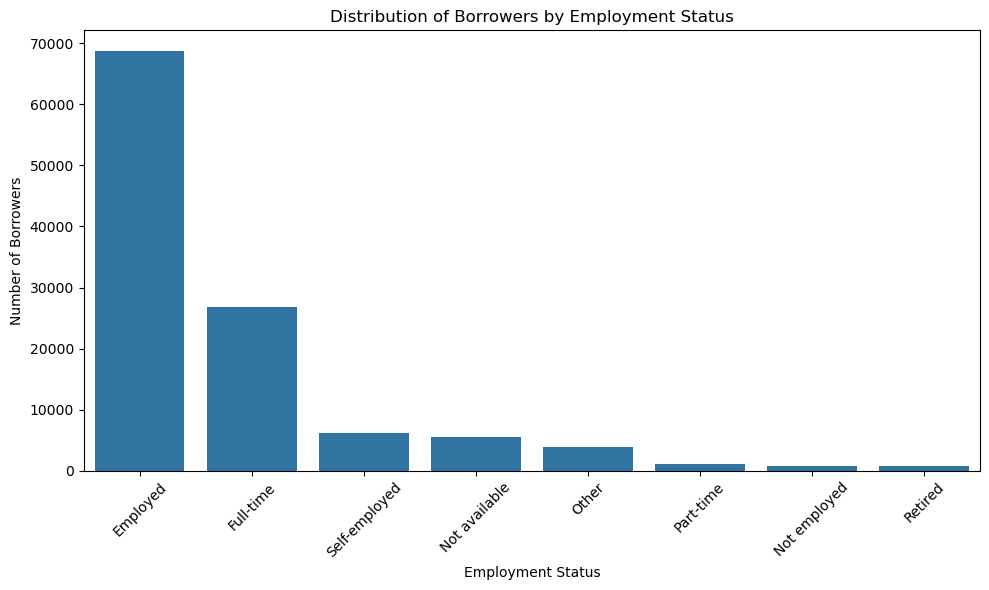

```python
plt.figure(figsize=(10, 6))
sns.countplot(data=df, x='EmploymentStatus', order=df['EmploymentStatus'].value_counts().index)
plt.title('Distribution of Borrowers by Employment Status')
plt.xlabel('Employment Status')
plt.ylabel('Number of Borrowers')
plt.xticks(rotation=45)
plt.tight_layout()
plt.show()
```

## Insight 1: Who Are the Borrowers?

The majority of loan applicants in this dataset are **Employed** or **Full-time** workers.  
These two categories make up the vast majority of borrowers, suggesting that most loans are issued to individuals with stable or formal employment.

Borrowers labeled as **Self-employed**, **Part-time**, or **Not employed** represent a much smaller portion.

## This may indicate that employment status is a significant factor in both loan approval and application behavior.

# 2. Does Employment Status Affect Borrower Interest Rates?

This chart explores how borrower interest rates (`BorrowerRate`) vary across different employment types.

It helps us understand whether certain job categories are associated with higher or more variable loan rates.

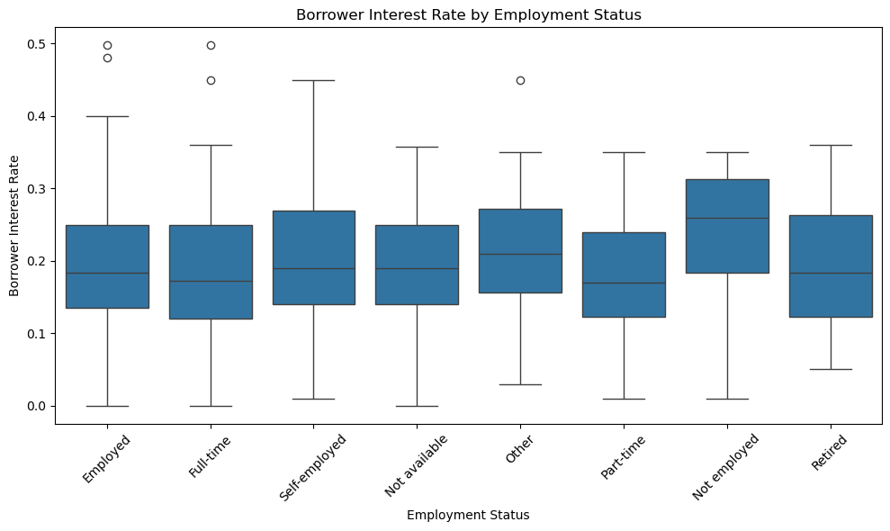

```python
plt.figure(figsize=(10, 6))
sns.boxplot(data=df, x='EmploymentStatus', y='BorrowerRate', order=df['EmploymentStatus'].value_counts().index)
plt.title('Borrower Interest Rate by Employment Status')
plt.xlabel('Employment Status')
plt.ylabel('Borrower Interest Rate')
plt.xticks(rotation=45)
plt.tight_layout()
plt.show()
```

# Observation:

# 3. Do Debt Levels Differ Between Open and Closed Loans?

This chart compares the `DebtToIncomeRatio` between loans that are still **open** and those that are **closed**.

It helps identify whether high debt burdens are more common in loans that ended (either repaid or defaulted).

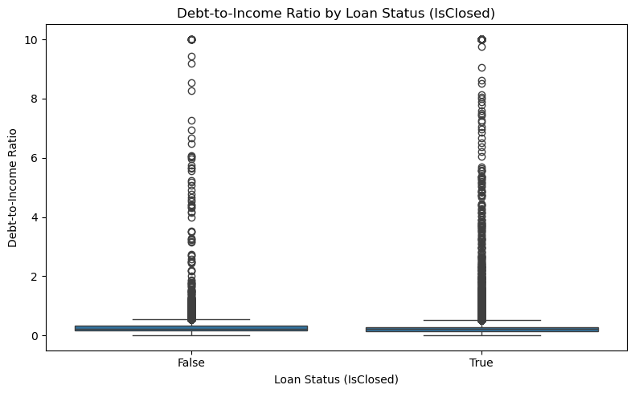

```python
plt.figure(figsize=(8, 5))
sns.boxplot(data=df, x='IsClosed', y='DebtToIncomeRatio')
plt.title('Debt-to-Income Ratio by Loan Status (IsClosed)')
plt.xlabel('Loan Status (IsClosed)')
plt.ylabel('Debt-to-Income Ratio')
plt.tight_layout()
plt.show()
```

# Debt-to-Income Ratio by Loan Status

This chart compares the DebtToIncomeRatio between loans that are still open (False) and those that have been closed (True).

It helps us assess whether borrowers with higher debt burdens are more likely to close out loans—either by paying off, refinancing, or defaulting.

## What we observe:

Both open and closed loans have a similar median debt-to-income ratio.

# How Do Financial Traits Interact with Loan Status?

In this pairplot, we explore the relationships between multiple key numeric variables and how they relate to the loan status (IsClosed). By visualizing these features together, we can uncover multivariate patterns that might not be visible when analyzing variables in isolation.

This helps in identifying potential risk signals from borrower profiles

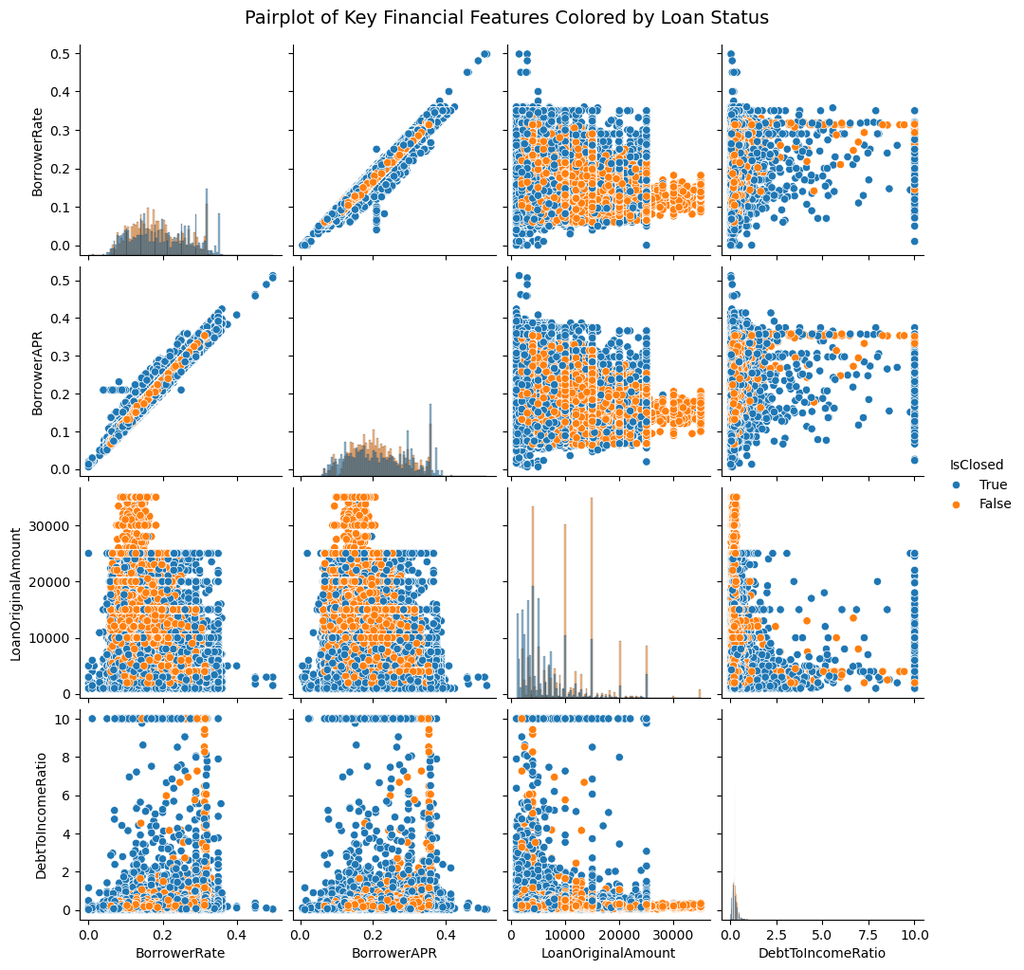

```python
selected_cols = ['BorrowerRate', 'BorrowerAPR', 'LoanOriginalAmount', 'DebtToIncomeRatio', 'IsClosed']
pairplot_df = df[selected_cols].copy()
pairplot_df['IsClosed'] = pairplot_df['IsClosed'].astype(str)

sns.pairplot(data=pairplot_df, hue='IsClosed', diag_kind='hist', height=2.5)
plt.suptitle("Pairplot of Key Financial Features Colored by Loan Status", fontsize=14, y=1.02)
plt.show()
```

# Key Takeaways from the Pairplot:

BorrowerRate and BorrowerAPR show a very strong linear relationship — which is expected since they represent closely related interest terms.

These findings highlight how certain combinations of features — rather than individual ones — may indicate borrower risk more effectively.

# Conclusion

This analysis explored key borrower characteristics and how they relate to loan outcomes — whether the loan is still open or has been closed.

By combining visual tools like bar charts, boxplots, and pairplots, we uncovered patterns in borrower behavior, employment status, interest rates, and financial ratios.

# Summary of Findings

Borrower Employment Status:

Most borrowers are "Employed" or "Full-time".

Interest Rate Patterns:

Boxplots showed that employment categories like "Self-employed" and "Not employed" tend to have higher interest rate variability.

Debt-to-Income Ratio and Loan Status:

Both open and closed loans have similar median debt ratios.

Multi-Variable Insights:

The pairplot revealed a strong correlation between BorrowerRate and BorrowerAPR.

It also helped us detect subtle differences in LoanOriginalAmount and DebtToIncomeRatio between open and closed loans.

# Reflection

During this analysis, we:

Cleaned the dataset and handled missing values.

Explored the most relevant univariate, bivariate, and multivariate features.

Built clear and annotated visualizations that communicate findings to both technical and non-technical audiences.

Practiced turning raw data into useful, interpretable insights.

# Final Thought

This exploration offers valuable direction for future modeling or policy design: Borrower risk profiles — as reflected in employment status, debt levels, and loan amounts — carry meaningful signals that lenders can use to improve decision-making.

## "These insights can directly inform loan approval policies or credit scoring models — helping lenders offer personalized, fairer financial products based on a borrower's true profile."